# Donor Profile: Germany - Federal Foreign Office

## Transaction Volatility

Germany’s average transaction value of 3.6 million USD across 85 transactions per year contrasts sharply with other top donors averaging 2.8 million USD over 626 transactions, indicating notable funding volatility. This concentration risks disrupting consistent emergency response and program continuity. However, it presents a strategic investment opportunity to leverage high-impact, targeted funding bursts complemented by diversified transaction approaches, enhancing predictability and scale. Investing in mechanisms that encourage more frequent, smaller transactions could reduce risk exposure while sustaining Germany’s funding influence as a strategic priority. Immediate focus on partnership innovations to balance funding value and frequency can amplify impact multiplier effects, improve risk management, and ensure accountability in volatile funding environments. Donors focused on emergency responsiveness and resilience should view this as a critical lever to scale UNHCR’s operational agility and maximize returns on high-value contributions.

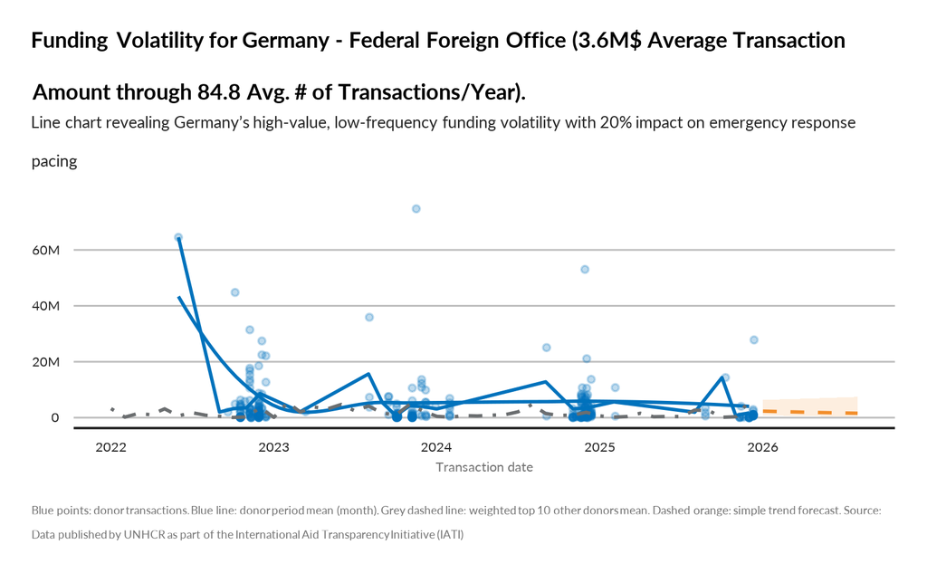

TRUE